# Lazy Plotting Gamblers Ruin

A friend of mine once told me a 'flawless' tactic for beating the roulette game.

```
1. bet on black
  - if you loose, bet on black again but now double the amount
    - if you win now, you will have not lost any money
    - if you loose again, bet on black again but now double the amount
      - if you win now, you will have not lost any money
      - if you loose again, bet on black again but now double the amount
        - if you win now, you will have not lost any money
        - if you loose again, bet on black again but now double the amount
          etc ...
  - if you win, profit!
2. repeat
```

The idea is that the probability of always getting red is zero and as of such you will always be able to win lost money back.

In this document I will explain why this tactic is flawed via probability theory as well as simulations. As a seperate goal, this document will also help explain simulation and lazy plotting patterns in R.

## Used Libraries

```r
set.seed(1)
library(ggplot2)
library(dplyr)
```

## Simulating Gambles in R

Let's start by first simulating and drawing a random path. For these first simulations we will assume that everytime you gamble you win some or loose some depending on the output of a cointoss. A possible way of simulating this can be via;

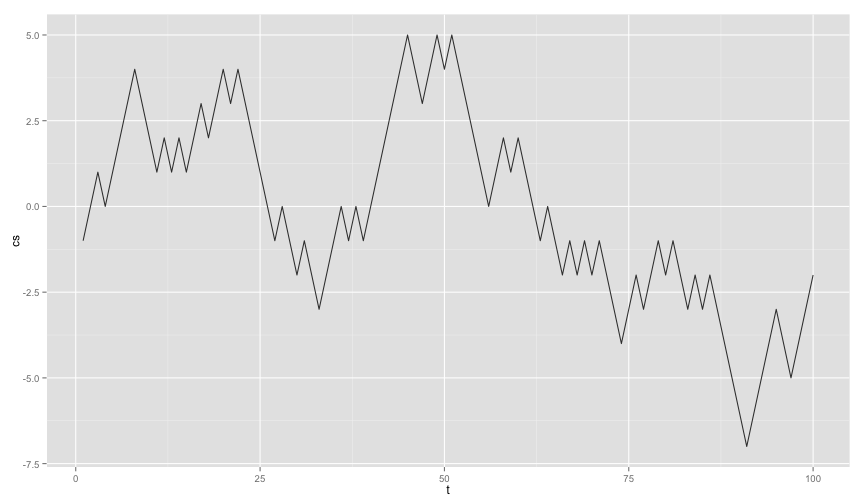

```r
randints = function(num) {
    sample(c(-1, 1), num, replace = TRUE)
}

df1 = data.frame(cs = cumsum(randints(100)), t = 1:100)
ggplot() + geom_line(data = df1, aes(t, cs), alpha = 0.8)
```

Simulating another such line and adding that to the plot is relatively straightforward.

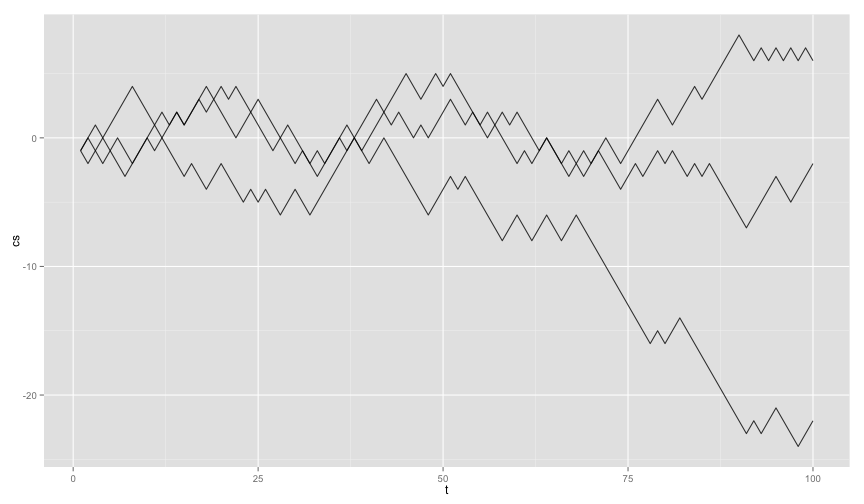

```r
df2 = data.frame(cs = cumsum(randints(100)), t = 1:100)
df3 = data.frame(cs = cumsum(randints(100)), t = 1:100)
ggplot() + geom_line(data = df1, aes(t, cs), alpha = 0.8) + geom_line(data = df2,
    aes(t, cs), alpha = 0.8) + geom_line(data = df3, aes(t, cs), alpha = 0.8)
```

The code can be made more elegant by exploiting the lazy evaluation of the ggplot2 library. You don't need to write a single line of `... + geom_line() + geom_line() + ...` code. You can append it to a variable instead.

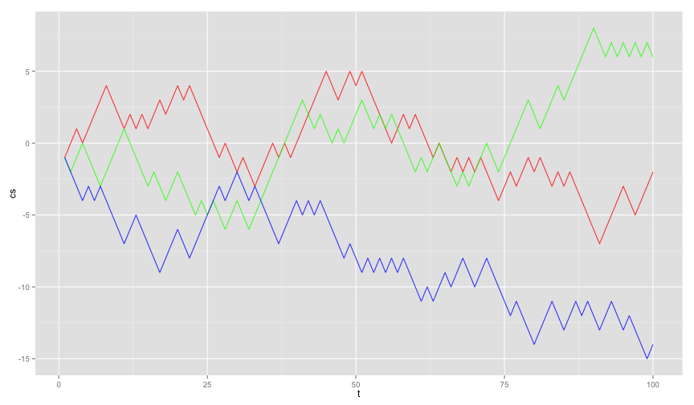

```r
df3 = data.frame(cs = cumsum(randints(100)), t = 1:100)
p = ggplot()
p = p + geom_line(data = df1, aes(t, cs), alpha = 0.8, color = "red")
p = p + geom_line(data = df2, aes(t, cs), alpha = 0.8, color = "green")
p = p + geom_line(data = df3, aes(t, cs), alpha = 0.8, color = "blue")
p
```

This is a more favorable pattern. You can keep adding plotting layers (from different datasets) to the variable `p` and it will not draw a single pixel until you call `p` at the end. It is clear for a user to see, line by line, that new layers are being added to the layer and you can use this pattern within a forloop. This means that you can do many simulations and draw them from a single function.

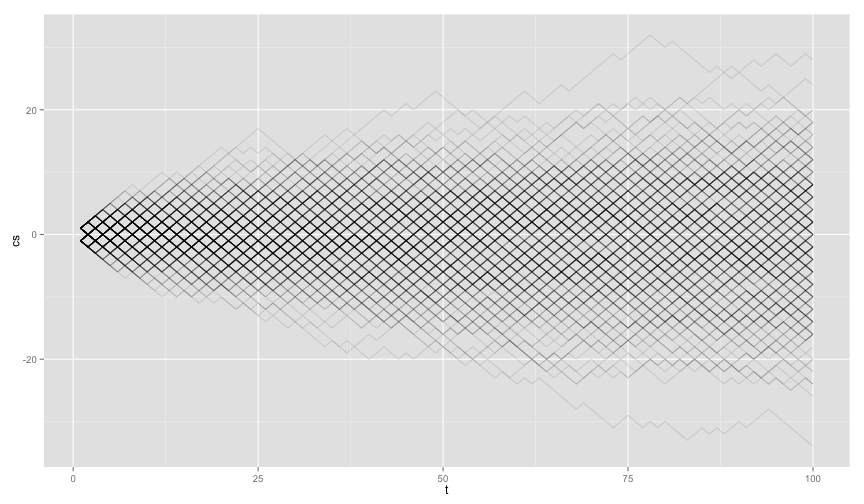

```r
gamble_plot = function(nruns) {
    p = ggplot()
    for (i in 1:nruns) {
        df = data.frame(cs = cumsum(randints(100)), t = 1:100)
        p = p + geom_line(data = df, aes(t, cs), alpha = 0.1)
    }
    p
}

gamble_plot(300)
```

In this pattern it is also relatively easy to assign colors to series of gamblers if they result in a long term profit or loss. Also, it might make sense to have the length of the random path be an input for our simulation function.

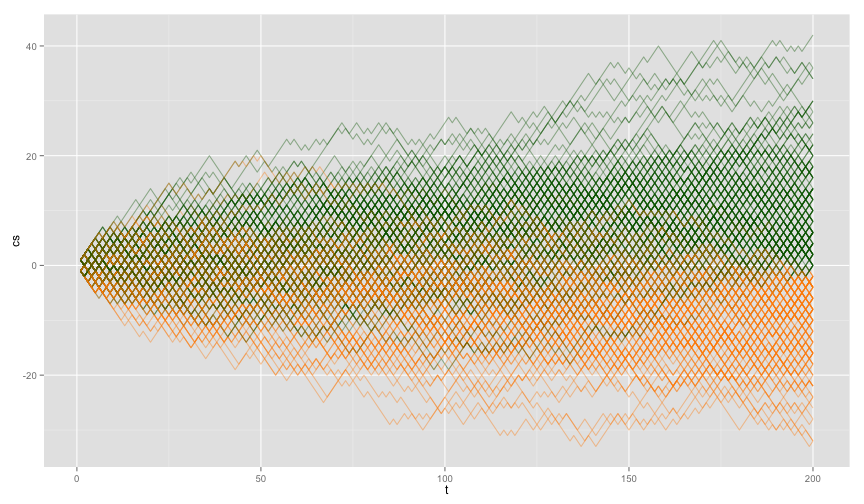

```r
gamble_plot = function(nruns, len) {
    p = ggplot()
    for (i in 1:nruns) {
        color = "darkgreen"
        df = data.frame(cs = cumsum(randints(len)), t = 1:len)
        if (select(df, cs)[len, ] < 0)
            color = "darkorange"
        p = p + geom_line(data = df, aes(t, cs), alpha = 0.4, color = color)
    }
    p
}

gamble_plot(300, 200)
```

### Casino Royale

Using this plotting pattern, let's simulate the results from the 'flawless' roulette tactic. The following functions help the simulation.

```r
gamble = function(moneyin) {
    if (runif(1) < 0.5)
        return(moneyin)  # result is black
    -moneyin  # result is red
}

nextm = function(gamble, outcome) {
    if (outcome < 0)
        return(2 * gamble)  #on loose we double the money
    1
}

simulate = function(maxt) {
    df = data.frame(time = as.numeric(c()), money = as.numeric(c()))
    move = 0
    outcome = 0
    for (i in 1:maxt) {
        move = nextm(move, outcome)
        outcome = gamble(move)
        df = rbind(df, data.frame(time = i, money = outcome))
    }
    df$money = cumsum(df$money)
    df
}

gamblersruin = function(num, maxsim) {
    p = ggplot()
    for (i in 1:num) {
        df = simulate(maxsim)
        p = p + geom_line(data = df, aes(time, money), alpha = 0.3)
    }
    p
}
```

Notice that I am assuming the probability of getting black (\( p_B \)) and the getting (\( p_R \)) to be equal to \( 0.5 \) for now. This is not how a casino would play roulette but we will use it as an upper bound. If I can show that in this optimistic version of roulette the outcome of this tactic is doubtful then it will surely fail in a more realistic roulette game. Later we will also consider a more realistic roulette game.

Let's run some results.

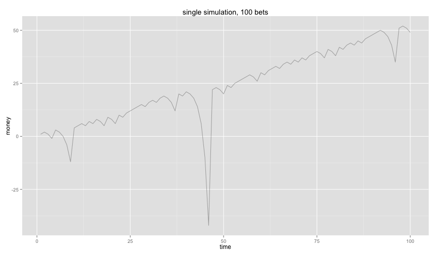

```r
set.seed(1)
gamblersruin(1, 100) + ggtitle("single simulation, 100 bets")
```

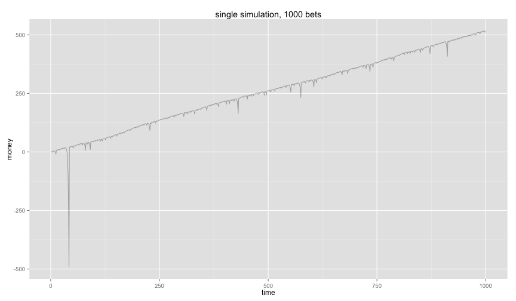

```r
gamblersruin(1, 1000) + ggtitle("single simulation, 1000 bets")
```

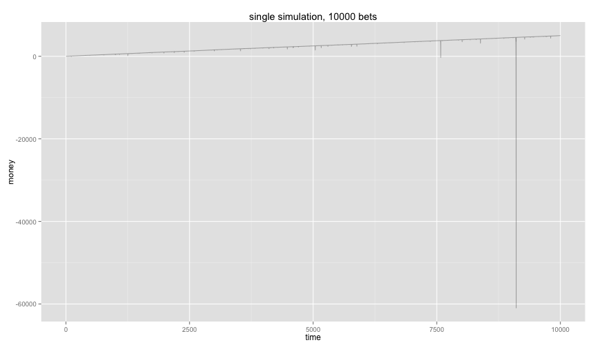

```r
gamblersruin(1, 10000) + ggtitle("single simulation, 10000 bets")
```

Ouch, on the long term it does seem like you are making a net profit but you are not without risk. The probability of getting red 12 times in a row is small but when you are playing this game for a very long time then this event suddenly becomes likely. And when it happens you need to compensate with \( 2^{12} \) cash.

### Probability Theory

So the simulations are giving us reasons to be pessimistic about the tactic, but the long term end result does seem to be positive. What does mathematics tell us?

I will be a bit formal here, but thats a given when dealing with math. Suppose that we play the game such we only play the roulette game until we have made a profit of 1. Let's consider this outcome to be a stochastic variable \( G \). Note that a single game \( G \) can have multiple bets.

Then also let \( p_B \) be the probability for getting black, \( p_R \) the probability for getting red, \( s_B \) the payout for getting the state of black and \( s_R \) the payout for getting the state of red.

\[ \begin{aligned} \mathbb{E}(G) & = p_Bs_B + p_Rs_R \\ & = \frac{1}{2} + \sum_{k=1}^\infty p_R^{k-1} p_B \times 0 = \frac{1}{2} \\ \end{aligned} \]

\[ \begin{aligned} \mathbb{E}(G^2) & = p_Bs_B^2 + p_Rs_R^2 \\ & = \frac{1}{2} + \sum_{k=1}^\infty p_R^{k-1} p_B \times 0 = \frac{1}{2}\\ \end{aligned} \]

The variance of the game is then defined via the definition.

\[ \begin{aligned} Var(G) & = \mathbb{E}(G^2) - [\mathbb{E}(G)]^2 \\ & = \frac{1}{2} - [\frac{1}{2}]^2 = \frac{1}{4}\\ \end{aligned} \]

So what happens when we play this game an infinite amount of time?

\[ \lim_{n\to\infty} \mathbb{E}(nG) = \lim_{n\to\infty} \frac{n}{2} = \infty \] \[ \lim_{n\to\infty} Var(nG) = \lim_{n\to\infty} \sum_{i=1}^n Var(G) = \infty \]

The game has infinite variance. You will definately need an infinite bank account if you want to make an infinite amount of money.

### Gamblers Fail

Even if we assume that you have an infinite amount of better money, the tactic will still fail in real life. Casinos are aware of this phenomenon and that is why casinos apply a maximum bet. You can never bet above a certain amount in the casino which means that you cannot apply the tactic infinetely.

How likely is it to hit a casino limit during a game? Let \( k \) be the number of sequential losses in a game and let \( n \) be the number of bets played. Then the probability of having no losses in one game is defined by the following.

\[ \mathbb{P}(\text{no loss in 1 game}) = 1 - \mathbb{P}(\text{loss in 1 game}) = 1 - \frac{1}{2^k} = \frac{2^k - 1}{2^k} \]

This can then be expanded to playing \( n \) games.

Notice that you cannot play the game for an infinite amount of time now without risking such a loss.

\[ \lim_{n\to\infty} 1 - \left( \frac{2^k-1}{2^k} \right)^n = 1, \forall k \geq 1 \]

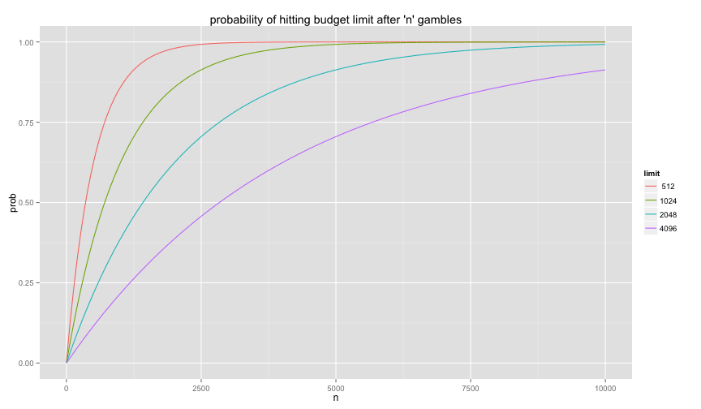

```r
f = function(k, n) {
    1 - ((2^k - 1)/(2^k))^n
}

df = data.frame(prob = f(9, 1:10000), n = 1:10000, limit = " 512")
df = rbind(df, data.frame(prob = f(10, 1:10000), n = 1:10000, limit = "1024"))
df = rbind(df, data.frame(prob = f(11, 1:10000), n = 1:10000, limit = "2048"))
df = rbind(df, data.frame(prob = f(12, 1:10000), n = 1:10000, limit = "4096"))

p = ggplot()
p = p + geom_line(data = df, aes(n, prob, colour = limit))
p + ggtitle("probability of hitting budget limit after 'n' gambles")
```

Also notice that if we consider the casino bounds then the expected value of the gamble suddenly becomes zero.

\[ \mathbb{E}(G) = p_B \times 1 - p_B{p_R}^{k-1} {2}^{k-1} = \frac{1}{2} - \frac{1}{2} = 0 \]

This conclusion changes further if we stop assuming that \( p_B = p_R = 0.5 \). In the more realistic casino game (by also considering the number 37 to the casino board) the expected value would now become:

\[ \mathbb{E}(G) = p_B \times 1 - p^B{p_R}^{k-1} {2}^{k-1} = 0.4865 - 0.5135 = -0.027 \]